# Predicting NFL Quarterback Fantasy Performance: A Data Science Analysis

# Fall 2025 Data Science Project

*Akhil Karumuri, Deep Mistry, Dev Patel, Sathvik Andhavarapu*

### Contributions

[output not shown]

# Introduction

## Motivation

Fantasy football has evolved from a casual pastime into a billion-dollar industry, with over 50 million people participating in fantasy leagues. One of the most important decisions to be made when drafting is selecting the right quarterback. QBs are often the highest-scoring position in fantasy formats, making their performance prediction crucial for fantasy success. As avid football fans who consistently watch NFL games, track player statistics, and compete in fantasy leagues, we wanted to explore a dataset that reflects our interests while allowing us to draw meaningful, data-driven conclusions.

The quarterback position presents unique analytical challenges for fantasy players. While some believe volume statistics like passing attempts are the key to fantasy success, others argue that draft pedigree or experience level matter more. These debates are often based on intuition or anecdotal evidence rather than rigorous statistical analysis. Our project aims to test these assumptions using real NFL data.

## Questions we want to answer

This project seeks to answer these key questions about quarterback fantasy performance:

1. **Does passing volume correlate with fantasy points per game?**
   - Is there a significant relationship between pass attempts per game and fantasy points per game?
2. **Does draft position correlate with fantasy points per game?**
   - Do early round quarterbacks significantly outperform late round draft picks in fantasy scoring?
3. **Does experience level correlate fantasy points per game?**
   - Do veteran QBs (with more career games) perform significantly better than rookies or early-career players?
4. **Can machine learning effectively predict fantasy points per game?**
   - Which features are most important?

## Why This Matters

Understanding what drives quarterback fantasy performance has several practical applications:

- **Fantasy Draft Strategy**: Provides evidence for whether to prioritize high-volume passers, highly-drafted prospects, or experienced veterans
- **Player Valuation**: Helps identify whether traditional scouting metrics (draft position) align with actual fantasy production
- **Decision Making**: Lets fantasy managers to make data-driven roster decisions instead of relying on hype or their knowledge.

Beyond fantasy football, this analysis shows the complete data science workflow. It starts from data curation and exploratory analysis through hypothesis testing and also machine learning while using a real-world dataset that fans care about. Whether you're optimizing your fantasy lineup or simply curious about what makes quarterbacks successful, this project provides a framework for answering these questions with data.

# Data Curation

Our dataset comes from Kaggle: [NFL Stats 1999-2022 by Philip Hyde](https://www.kaggle.com/datasets/philiphyde1/nfl-stats-1999-2022). Specifically, we use the yearly_player_stats_offense.csv file, which contains comprehensive offensive statistics for NFL players across multiple seasons.

This dataset includes player information (ID, name, position, birth year, physical measurements), draft data (draft year, round, pick number, overall selection), season statistics (passing, rushing, and receiving metrics aggregated by season), advanced metrics (passer rating, air yards, red zone performance, and more), and career information (years of experience, games played)

The dataset originally contains **660 columns** covering nearly every offensive statistic tracked by the NFL from 2012-2024 which makes it ideal for comprehensive analysis of player performance.

```python
import pandas as pd

df = pd.read_csv('yearly_player_stats_offense.csv')
print(df.head())
```

```
    player_id      player_name position  birth_year  draft_year  draft_round  \
0  00-0000865    Charlie Batch       QB        1974      1998.0          2.0
1  00-0004541    Donald Driver       WR        1975      1999.0          7.0
2  00-0006101    Tony Gonzalez       TE        1976      1997.0          1.0
3  00-0006101    Tony Gonzalez       TE        1976      1997.0          1.0
4  00-0007091  Matt Hasselbeck       QB        1975      1998.0          6.0

   draft_pick  draft_ovr  height  weight  ... delta_comp_pct  delta_int_pct  \
0        30.0       60.0    74.0   216.0  ...       0.220036           -1.0
1         7.0      213.0    72.0   194.0  ...       0.000000            NaN
2        13.0       13.0    77.0   247.0  ...       0.000000            0.0
3        13.0       13.0    77.0   247.0  ...       0.000000            NaN
4        34.0      187.0    76.0   235.0  ...       0.149281           -1.0

  delta_pass_td_pct delta_ypa delta_yptarget delta_ypr  delta_rush_td_pct  \
0              -1.0  0.025641       0.000000  0.000000                0.0
1               NaN  0.000000      -0.172028 -0.068732                0.0
2               0.0  0.000000       0.273859 -0.216170                0.0
3               NaN  0.000000      -0.165038  0.085776                0.0
4              -1.0 -0.162698       0.000000  0.000000               -1.0

   delta_ypc  delta_td_pct  delta_yptouch
0   0.000000     -0.909091      -0.388795
1   0.000000     49.000000       1.226852
2   0.000000      3.833333       0.236242
3   0.000000     -0.413793       0.085776
4  -0.337868      0.500000       0.250509

[5 rows x 660 columns]
```

```python
num_columns = df.shape[1]
print(f"Number of columns: {num_columns}")
```

```
Number of columns: 660
```

We have decided to only focus on the below columns, as 660 columns is way too much data. We selected 19 key columns that help us in our experiment.

```python
keep_cols = [
    'player_id', 'position', 'games_played_season', 'season',
    'season_pass_attempts', 'rush_attempts', 'pass_attempts_redzone', 'pass_attempts_gtg', 'season_offense_snaps',
    'passer_rating', 'season_passing_air_yards', 'season_complete_pass', 'season_complete_pass_redzone', 'season_complete_pass_gtg',
    'years_exp', 'games_played_career',
    'draft_ovr', 'draft_round',
    'fantasy_points_ppr'
]

# Quarterbacks
# Dependent Variable: PPR fantasy points per game
# Independent Variables:
  # Volume: pass attempts per game, designed rush attempts per game, scrambles per game, redzone pass attempts per game, goal-to-go pass attempts per game, snaps per game,
  # Efficiency: passer rating, passing air yards per attempt, completion percentage, redzone completion percentage, goal-to-go completion percentage
  # Experience: years of experience, career games played
  # Draft Pick: draft pick (overall)


df = df[keep_cols]
```

```python
df
```

|  | player_id | position | games_played_season | season | season_pass_attempts | rush_attempts | pass_attempts_redzone | pass_attempts_gtg | season_offense_snaps | passer_rating | season_passing_air_yards | season_complete_pass | season_complete_pass_redzone | season_complete_pass_gtg | years_exp | games_played_career | draft_ovr | draft_round | fantasy_points_ppr |
| --- | --- | --- | --- | --- | --- | --- | --- | --- | --- | --- | --- | --- | --- | --- | --- | --- | --- | --- | --- |
| 0 | 00-0000865 | QB | 2 | 2012 | 66.0 | 0.0 | 2.0 | 0.0 | 129.0 | 68.69 | 663.0 | 45.0 | 2.0 | 0.0 | 14.0 | 2 | 60.0 | 2.0 | 17.00 |
| 1 | 00-0004541 | WR | 9 | 2012 | 0.0 | 0.0 | 0.0 | 0.0 | 121.0 | 0.00 | 0.0 | 0.0 | 0.0 | 0.0 | 13.0 | 9 | 213.0 | 7.0 | 27.70 |
| 2 | 00-0006101 | TE | 2 | 2012 | 0.0 | 0.0 | 0.0 | 0.0 | 122.0 | 0.00 | 0.0 | 0.0 | 0.0 | 0.0 | 15.0 | 2 | 13.0 | 1.0 | 36.90 |
| 3 | 00-0006101 | TE | 16 | 2012 | 0.0 | 0.0 | 0.0 | 0.0 | 966.0 | 0.00 | 0.0 | 0.0 | 0.0 | 0.0 | 15.0 | 16 | 13.0 | 1.0 | 228.00 |
| 4 | 00-0007091 | QB | 8 | 2012 | 216.0 | 13.0 | 22.0 | 4.0 | 395.0 | 82.85 | 1707.0 | 138.0 | 12.0 | 1.0 | 14.0 | 8 | 187.0 | 6.0 | 87.48 |
| ... | ... | ... | ... | ... | ... | ... | ... | ... | ... | ... | ... | ... | ... | ... | ... | ... | ... | ... | ... |
| 7128 | 00-0039917 | QB | 5 | 2024 | 102.0 | 7.0 | 15.0 | 1.0 | 230.0 | 81.13 | 1073.0 | 61.0 | 8.0 | 0.0 | 0.0 | 5 | 8.0 | 1.0 | 50.10 |
| 7129 | 00-0039918 | QB | 17 | 2024 | 556.0 | 81.0 | 72.0 | 10.0 | 1123.0 | 88.72 | 4486.0 | 351.0 | 36.0 | 6.0 | 0.0 | 17 | 1.0 | 1.0 | 283.54 |
| 7130 | 00-0039919 | WR | 17 | 2024 | 0.0 | 3.0 | 0.0 | 0.0 | 954.0 | 0.00 | 0.0 | 0.0 | 0.0 | 0.0 | 0.0 | 17 | 9.0 | 1.0 | 141.90 |
| 7131 | 00-0039920 | WR | 5 | 2024 | 0.0 | 2.0 | 0.0 | 0.0 | 76.0 | 0.00 | 0.0 | 0.0 | 0.0 | 0.0 | 0.0 | 5 | 65.0 | 3.0 | 4.20 |
| 7132 | 00-0039921 | RB | 12 | 2024 | 0.0 | 63.0 | 0.0 | 0.0 | 133.0 | 0.00 | 0.0 | 0.0 | 0.0 | 0.0 | 0.0 | 12 | 66.0 | 3.0 | 47.00 |

7133 rows × 19 columns

```python
# Cleaning the DF

# Keep 2010-present
df = df[df['position'] == "QB"]
df = df[df['season'] > 2012]

# Clean the duplicate IDs
df['unique_id'] = df['player_id'].astype(str) + '_' + df['season'].astype(str)
df = df.sort_values(by=['unique_id', 'games_played_season'], ascending=[True, False])
df = df.drop_duplicates(subset='unique_id', keep='first')

# per game metrics
df['fantasy_points_ppr_per_game'] = df['fantasy_points_ppr'] / df['games_played_season']
df['pass_attempts_per_game'] = df['season_pass_attempts'] / df['games_played_season']
df['rush_attempts_per_game'] = df['rush_attempts'] / df['games_played_season']
df['redzone_pass_attempts_per_game'] = df['pass_attempts_redzone'] / df['games_played_season']
df['goal_to_go_pass_attempts_per_game'] = df['pass_attempts_gtg'] / df['games_played_season']
df['snaps_per_game'] = df['season_offense_snaps'] / df['games_played_season']
df['passing_air_yards_per_game'] = df['season_passing_air_yards'] / df['games_played_season']
df['complete_pass_per_game'] = df['season_complete_pass'] / df['games_played_season']
df['complete_pass_redzone_per_game'] = df['season_complete_pass_redzone'] / df['games_played_season']
df['complete_pass_goal_to_go_per_game'] = df['season_complete_pass_gtg'] / df['games_played_season']


df
```

|  | player_id | position | games_played_season | season | season_pass_attempts | rush_attempts | pass_attempts_redzone | pass_attempts_gtg | season_offense_snaps | passer_rating | ... | fantasy_points_ppr_per_game | pass_attempts_per_game | rush_attempts_per_game | redzone_pass_attempts_per_game | goal_to_go_pass_attempts_per_game | snaps_per_game | passing_air_yards_per_game | complete_pass_per_game | complete_pass_redzone_per_game | complete_pass_goal_to_go_per_game |
| --- | --- | --- | --- | --- | --- | --- | --- | --- | --- | --- | --- | --- | --- | --- | --- | --- | --- | --- | --- | --- | --- |
| 412 | 00-0007091 | QB | 3 | 2013 | 11.0 | 2.0 | 3.0 | 2.0 | 23.0 | 66.48 | ... | 1.000000 | 3.666667 | 0.666667 | 1.000000 | 0.666667 | 7.666667 | 25.666667 | 2.333333 | 0.000000 | 0.000000 |
| 832 | 00-0007091 | QB | 4 | 2014 | 44.0 | 8.0 | 7.0 | 1.0 | 82.0 | 102.56 | ... | 4.985000 | 11.000000 | 2.000000 | 1.750000 | 0.250000 | 20.500000 | 78.250000 | 7.500000 | 0.750000 | 0.250000 |
| 1312 | 00-0007091 | QB | 8 | 2015 | 251.0 | 16.0 | 35.0 | 8.0 | 458.0 | 85.58 | ... | 13.387500 | 31.375000 | 2.000000 | 4.375000 | 1.000000 | 57.250000 | 237.500000 | 19.500000 | 2.125000 | 0.625000 |
| 414 | 00-0010346 | QB | 16 | 2013 | 649.0 | 32.0 | 117.0 | 34.0 | 1156.0 | 116.86 | ... | 32.123750 | 40.562500 | 2.000000 | 7.312500 | 2.125000 | 72.250000 | 323.062500 | 28.125000 | 5.187500 | 1.250000 |
| 834 | 00-0010346 | QB | 16 | 2014 | 582.0 | 24.0 | 108.0 | 30.0 | 1094.0 | 104.08 | ... | 24.042500 | 36.375000 | 1.500000 | 6.750000 | 1.875000 | 68.375000 | 316.937500 | 24.687500 | 4.437500 | 0.937500 |
| ... | ... | ... | ... | ... | ... | ... | ... | ... | ... | ... | ... | ... | ... | ... | ... | ... | ... | ... | ... | ... | ... |
| 7084 | 00-0039732 | QB | 17 | 2024 | 555.0 | 92.0 | 76.0 | 11.0 | 1088.0 | 95.89 | ... | 22.070588 | 32.647059 | 5.411765 | 4.470588 | 0.647059 | 64.000000 | 242.117647 | 22.117647 | 2.882353 | 0.470588 |
| 7107 | 00-0039851 | QB | 13 | 2024 | 328.0 | 54.0 | 39.0 | 11.0 | 681.0 | 90.70 | ... | 15.164615 | 25.230769 | 4.153846 | 3.000000 | 0.846154 | 52.384615 | 190.230769 | 17.307692 | 1.692308 | 0.307692 |
| 7123 | 00-0039910 | QB | 17 | 2024 | 471.0 | 149.0 | 67.0 | 13.0 | 1062.0 | 101.94 | ... | 23.518824 | 27.705882 | 8.764706 | 3.941176 | 0.764706 | 62.470588 | 208.705882 | 19.470588 | 2.529412 | 0.529412 |
| 7128 | 00-0039917 | QB | 5 | 2024 | 102.0 | 7.0 | 15.0 | 1.0 | 230.0 | 81.13 | ... | 10.020000 | 20.400000 | 1.400000 | 3.000000 | 0.200000 | 46.000000 | 214.600000 | 12.200000 | 1.600000 | 0.000000 |
| 7129 | 00-0039918 | QB | 17 | 2024 | 556.0 | 81.0 | 72.0 | 10.0 | 1123.0 | 88.72 | ... | 16.678824 | 32.705882 | 4.764706 | 4.235294 | 0.588235 | 66.058824 | 263.882353 | 20.647059 | 2.117647 | 0.352941 |

794 rows × 30 columns

# Exploratory Data Analysis

### **Analysis 1:**

This analysis aims to answer the research question: Is there a correlation between pass attempts per game and fantasy points per game? We use pearson correlation coefficient to measure the strength and direction of the linear relationship.

```
count    794.000000
mean      23.350123
std       12.499961
min        0.000000
25%       12.156250
50%       27.702941
75%       33.079167
max       44.000000
Name: pass_attempts_per_game, dtype: float64

Pearson r: 0.8437904323003788, p-value: 2.8574791318279726e-216
```

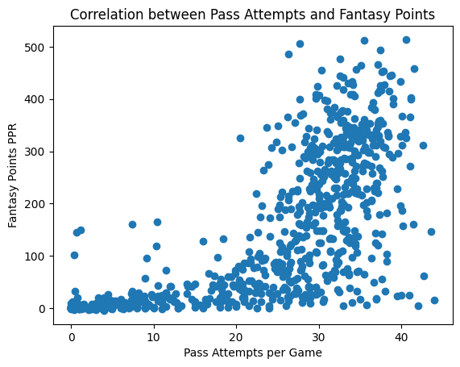

```python
# Volume
# Scatter Plot for a visual: Correlation between passing_attempts_per_game and fantasy_points_ppr (Pearson correlation)
from scipy.stats import pearsonr
import matplotlib.pyplot as plt

# Summary statistics for pass_attempts_per_game
print(df['pass_attempts_per_game'].describe())
print()

r, p = pearsonr(df['pass_attempts_per_game'], df['fantasy_points_ppr_per_game'])
print(f"Pearson r: {r}, p-value: {p}")

plt.scatter(df['pass_attempts_per_game'], df['fantasy_points_ppr'])
plt.xlabel('Pass Attempts per Game')
plt.ylabel('Fantasy Points PPR')
plt.title('Correlation between Pass Attempts and Fantasy Points')
plt.show()
```

### **Analysis 2:**

This analysis aims to answer the research question: Do QBs drafted in early rounds (1-3) score significantly more fantasy points per game than those drafted in later rounds (>3)? We use a two-sample t-test to compare mean fantasy points per game between high draft capital (rounds 1-3) and low draft capital (rounds >3) QBs.

```
T-Test (Draft Capital vs. Fantasy Points) Results
T-statistic: 9.6785, P-value: 0.0000
```

[figure not shown]

```python
# Correlation between round QB was drafted and fantasy_points_ppr
import numpy as np
from scipy.stats import ttest_ind
import seaborn as sns

df_qb = df[df['position'] == 'QB'].copy()
df_qb.dropna(subset=['games_played_season', 'fantasy_points_ppr', 'season_pass_attempts'], inplace=True)
df_qb = df_qb[df_qb['games_played_season'] > 0]
df_qb['fantasy_points_ppr_per_game'] = df_qb['fantasy_points_ppr'] / df_qb['games_played_season']

#T-Test Analysis
df_qb['draft_round_cleaned'] = df_qb['draft_round'].fillna(8) #Undrafted

# Create two groups
high_capital = df_qb[df_qb['draft_round_cleaned'] <= 3]['fantasy_points_ppr_per_game'].dropna()
low_capital = df_qb[df_qb['draft_round_cleaned'] > 3]['fantasy_points_ppr_per_game'].dropna()

# Two-sample t-test
t_stat, p_t_test = ttest_ind(high_capital, low_capital, equal_var=False)

print("T-Test (Draft Capital vs. Fantasy Points) Results")
print(f"T-statistic: {t_stat:.4f}, P-value: {p_t_test:.4f}")

# Box plot
plt.figure(figsize=(8, 6))
df_qb['Draft_Group'] = np.where(df_qb['draft_round_cleaned'] <= 2, 'High Capital (Rds 1-3)', 'Low Capital (Rds 4-7)')
sns.boxplot(x='Draft_Group', y='fantasy_points_ppr_per_game', data=df_qb, hue='Draft_Group', palette=['skyblue', 'lightgreen'])
plt.title(f'Fantasy Points PPR/G by Draft Capital Group', fontsize=14)
plt.xlabel('Draft Capital Group', fontsize=12)
plt.ylabel('Fantasy Points PPR Per Game', fontsize=12)
plt.grid(axis='y', linestyle='--', alpha=0.5)
```

### **Analysis 3**

This analysis aims to answer the research question: Do fantasy points per game differ significantly across career stages?

**Method:** ANOVA (Analysis of Variance) test to compare means across four experience groups:

- **Rookie**: ≤16 games played
- **Early Career**: 17-48 games played
- **Mid-Career**: 49-96 games played
- **Veteran**: >96 games played

If significant, we'll use Tukey HSD post-hoc test to identify which specific groups differ.

```
count    794.000000
mean      43.144836
std       40.184762
min        1.000000
25%       13.000000
50%       30.000000
75%       63.000000
max      199.000000
Name: games_played_career, dtype: float64
P-value: 0.000
 Multiple Comparison of Means - Tukey HSD, FWER=0.05
======================================================
group1  group2 meandiff p-adj   lower    upper  reject
------------------------------------------------------
 Early     Mid   3.8211    0.0   2.0138  5.6284   True
 Early  Rookie  -5.9126    0.0  -7.5196 -4.3056   True
 Early Veteran   5.5114    0.0   3.2214  7.8013   True
   Mid  Rookie  -9.7337    0.0 -11.5424  -7.925   True
   Mid Veteran   1.6902 0.2805  -0.7455   4.126  False
Rookie Veteran   11.424    0.0   9.1329  13.715   True
------------------------------------------------------
```

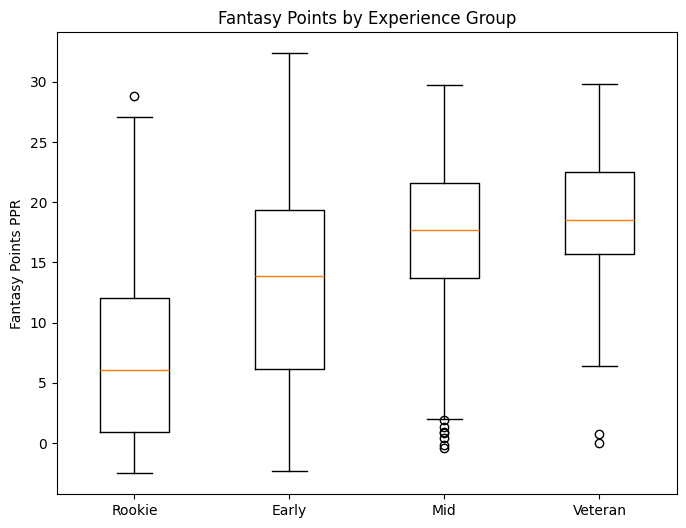

```python
# Experience
# Hypothesis Test: Do fantasy points per game significantly differ across different levels of experience (career games played)
# Use ANOVA test: Rookie (<=16 games played), Early Career (16-48 games played), Mid Career (48-96 games played), Veteran (>96 games played)
from scipy.stats import f_oneway
from statsmodels.stats.multicomp import pairwise_tukeyhsd

bins = [0, 16, 48, 96, 500]
labels = ['Rookie', 'Early', 'Mid', 'Veteran']
def experience_group(games):
    if games <= 16:
        return 'Rookie'
    elif games <= 48:
        return 'Early'
    elif games <= 96:
        return 'Mid'
    else:
        return 'Veteran'

df['exp_group'] = df['games_played_career'].apply(experience_group)

groups = [df[df['exp_group'] == label]['fantasy_points_ppr_per_game'] for label in labels]

print(df['games_played_career'].describe())

f_stat, p_val = f_oneway(*groups)
print(f"P-value: {p_val:.3f}")

# P-value shows a statistically significant difference in means between the Experience Group and fantasy points per game
tukey = pairwise_tukeyhsd(endog=df['fantasy_points_ppr_per_game'],
                          groups=df['exp_group'],
                          alpha=0.05)
print(tukey)

# Box and Whisker plot to display the relationship between experience group and fantasy points per game
plt.figure(figsize=(8,6))
plt.boxplot(groups, tick_labels=labels)
plt.ylabel('Fantasy Points PPR')
plt.title('Fantasy Points by Experience Group')
plt.show()
```

### **Results/Analysis 3**

The ANOVA test shows that there is a statistically significant difference in fantasy points between quarterbacks of different experience levels, with a p-value of 0.000 which is well below 0.05. This means that experience level does have an impact on fantasy production. Based on the Tukey HSD test, all pairwise comparisons were statistically significant except for the Mid vs Veteran group. This shows that rookies, early-career, and mid-career quarterbacks tend to differ significantly in their average fantasy points, while mid-career and veteran quarterbacks perform similarly overall. Looking at the box plot, rookie quarterbacks (less than 17 games played) and early career quarterbacks (16-48 games played) tend to have the lowest fantasy output and the widest spread, showing high variability and inconsistency. This might be due to various different reasons. A lot of young quarterbacks don't get as much playing time, so they don't have as much opportunity to get fantasy points. Rookie quarterbacks also often tend to get drafted to struggling teams, which can limit their scores as well. Fantasy points generally increase through the early (16-48 games played) and mid (48-96 games played) stages of a quarterback’s career and then level off for the later years (more than 96 games played) of their career. In conclusion, quarterbacks tend to improve their fantasy scoring as they gain more experience, with production peaking in mid-career years before stabilizing at the veteran level, and this relationship is statistically significant (p < 0.05).

# Primary Analysis - Machine Learning Analysis

### Problem Setup

Our goal is to predict quarterback fantasy points per game based on their statistical performances. This is clearly a regression problem, as we are predicting a continuous numerical value in fantasy points per game.

### Why Linear Regression?

We chose to use linear regression for a variety of reasons. Firstly, with linear regression, it is very easy to interpret our results. We can easily see which stats matter most for fantasy football performance, as linear regression coefficients directly show the relationship between each stat and fantasy points. Intuitively, linear regression makes sense for this problem, as we'd expect that as QBs get more pass attempts, more snaps, or more redzone opportunities, their fantasy points should increase in a relatively proportional way. It is important to note that this does not account for collinearity, but individually each of those assumptions make sense intuitively. Additionally, linear regression is widely used in sports analytics and fantasy football research, making it a good starting point for our analysis.

### Why Introduce Lasso Regression?

Throughout the process up until this point, we noticed that multiple of our features (independent variables) are correlated with each other. For example, many of the passing stats are correlated with each other, such as passing attempts per game, passing attempts per game in the redzone, and then passing attempts per game in goal-to-go scenarios. This can cause problems, as we'll see coefficients of variables have odd values (as they will be biased, since the variance in fantasy points per game is better explained by a different independent variable). These biases make it harder to interpret our results, and make it harder to determine which statistics actually matter.

Lasso Regression solves this because it automatically shrinks unimportant features to a coefficient of 0. In addition, it performs feature selection, which means that it identifies the features that are most important to explaining the variance in fantasy points per game. It will make our results much easier to interpret.

### Training Approach

```
Training set: 572 QBs (seasons 2012-2021)
Test set: 222 QBs (seasons 2022-2024)

Train MSE: 6.6684, R²: 0.9079
Test MSE: 7.0698, R²: 0.8862
```

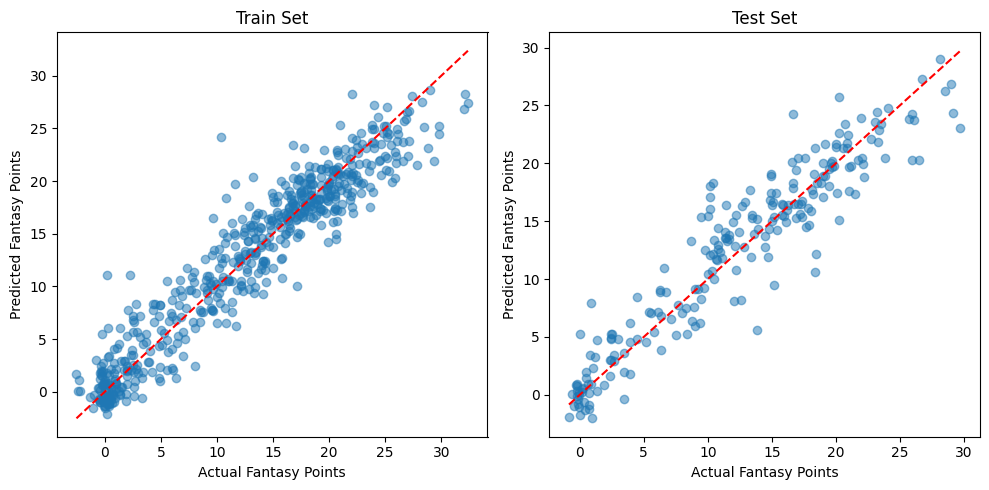

```
                             feature  coefficient
8  complete_pass_goal_to_go_per_game     3.025592
7     complete_pass_redzone_per_game     1.158409
6             complete_pass_per_game     1.142616
1             rush_attempts_per_game     0.921167
3  goal_to_go_pass_attempts_per_game     0.801465
2     redzone_pass_attempts_per_game     0.453578
4                     snaps_per_game     0.096874
5         passing_air_yards_per_game     0.040553
0             pass_attempts_per_game    -0.957378
```

```python
# Run Linear Regression Machine Learning Analysis on features defined earlier
from sklearn.linear_model import LinearRegression
from sklearn.model_selection import train_test_split
from sklearn.metrics import mean_squared_error, r2_score
import matplotlib.pyplot as plt
import numpy as np

# Select features and target
features = ['pass_attempts_per_game', 'rush_attempts_per_game', 'redzone_pass_attempts_per_game',
            'goal_to_go_pass_attempts_per_game', 'snaps_per_game', 'passing_air_yards_per_game',
            'complete_pass_per_game', 'complete_pass_redzone_per_game', 'complete_pass_goal_to_go_per_game']

X = df[features]
y = df['fantasy_points_ppr_per_game']

# Split the data - We are training our Linear Regression model on seasons 2012-2021, and testing the model on seasons 2022-2024
train_mask = df['season'] <= 2021
test_mask = df['season'] >= 2022

X_train = X[train_mask]
X_test = X[test_mask]
y_train = y[train_mask]
y_test = y[test_mask]

print(f"Training set: {len(X_train)} QBs (seasons 2012-2021)")
print(f"Test set: {len(X_test)} QBs (seasons 2022-2024)\n")

# Fit the model
model = LinearRegression()
model.fit(X_train, y_train)

# Predict
y_train_pred = model.predict(X_train)
y_test_pred = model.predict(X_test)

# Evaluate
mse_train = mean_squared_error(y_train, y_train_pred)
mse_test = mean_squared_error(y_test, y_test_pred)
r2_train = r2_score(y_train, y_train_pred)
r2_test = r2_score(y_test, y_test_pred)

print(f"Train MSE: {mse_train:.4f}, R²: {r2_train:.4f}")
print(f"Test MSE: {mse_test:.4f}, R²: {r2_test:.4f}")

# Plot predictions vs actual
plt.figure(figsize=(10, 5))
plt.subplot(1, 2, 1)
plt.scatter(y_train, y_train_pred, alpha=0.5)
plt.plot([y_train.min(), y_train.max()], [y_train.min(), y_train.max()], 'r--')
plt.xlabel('Actual Fantasy Points')
plt.ylabel('Predicted Fantasy Points')
plt.title('Train Set')

plt.subplot(1, 2, 2)
plt.scatter(y_test, y_test_pred, alpha=0.5)
plt.plot([y_test.min(), y_test.max()], [y_test.min(), y_test.max()], 'r--')
plt.xlabel('Actual Fantasy Points')
plt.ylabel('Predicted Fantasy Points')
plt.title('Test Set')
plt.tight_layout()
plt.show()

# Feature importance
feature_importance = pd.DataFrame({
    'feature': features,
    'coefficient': model.coef_
}).sort_values('coefficient', ascending=False)
print(feature_importance)
```

```python
# Lasso - want to see what the most important features are
from sklearn.linear_model import Lasso, LassoCV
from sklearn.preprocessing import StandardScaler

# Standardize features
scaler = StandardScaler()
X_train_scaled = scaler.fit_transform(X_train)
X_test_scaled = scaler.transform(X_test)

# Train Lasso model with best alpha, which we decided was 0.1
lasso = Lasso(alpha=0.1)
lasso.fit(X_train_scaled, y_train)

# Predict
y_train_pred_lasso = lasso.predict(X_train_scaled)
y_test_pred_lasso = lasso.predict(X_test_scaled)

# Evaluate
mse_train_lasso = mean_squared_error(y_train, y_train_pred_lasso)
mse_test_lasso = mean_squared_error(y_test, y_test_pred_lasso)
r2_train_lasso = r2_score(y_train, y_train_pred_lasso)
r2_test_lasso = r2_score(y_test, y_test_pred_lasso)

print(f"\nLasso Regression Results:")
print(f"Train MSE: {mse_train_lasso:.4f}, R²: {r2_train_lasso:.4f}")
print(f"Test MSE: {mse_test_lasso:.4f}, R²: {r2_test_lasso:.4f}")

# Show feature coefficients
print("\nFeature Importance (Lasso Coefficients):")
lasso_coefs = pd.DataFrame({
    'feature': features,
    'coefficient': lasso.coef_
}).sort_values('coefficient', key=abs, ascending=False)

print(lasso_coefs)
```

```
Lasso Regression Results:
Train MSE: 7.8419, R²: 0.8917
Test MSE: 7.9035, R²: 0.8728

Feature Importance (Lasso Coefficients):
                             feature  coefficient
7     complete_pass_redzone_per_game     2.651257
1             rush_attempts_per_game     1.948685
5         passing_air_yards_per_game     1.811702
6             complete_pass_per_game     1.670054
8  complete_pass_goal_to_go_per_game     1.088920
3  goal_to_go_pass_attempts_per_game     0.248855
2     redzone_pass_attempts_per_game     0.228693
4                     snaps_per_game     0.018656
0             pass_attempts_per_game     0.000000
```

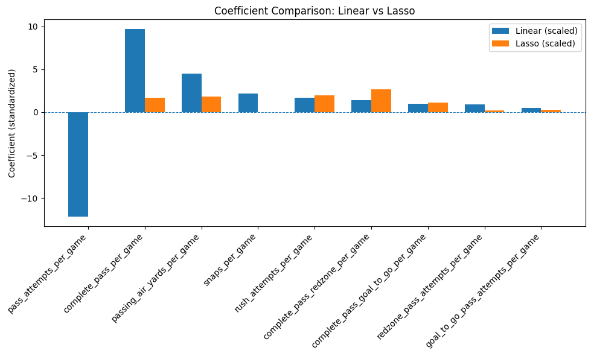

```python
lin_scaled = LinearRegression()
lin_scaled.fit(X_train_scaled, y_train)

coef_df = pd.DataFrame({
    'feature': features,
    'Linear (scaled)': lin_scaled.coef_,
    'Lasso (scaled)':  lasso.coef_
})

coef_long = coef_df.melt(
    id_vars='feature',
    value_vars=['Linear (scaled)', 'Lasso (scaled)'],
    var_name='model',
    value_name='coefficient'
)

feature_order = (
    coef_df.set_index('feature')['Linear (scaled)']
           .abs()
           .sort_values(ascending=False)
           .index
           .tolist()
)

coef_long['feature'] = pd.Categorical(
    coef_long['feature'],
    categories=feature_order,
    ordered=True
)
coef_long = coef_long.sort_values('feature')

x = np.arange(len(feature_order))
width = 0.35

linear_coefs = coef_long[coef_long['model'] == 'Linear (scaled)']['coefficient'].values
lasso_coefs  = coef_long[coef_long['model'] == 'Lasso (scaled)']['coefficient'].values

plt.figure(figsize=(10, 6))
plt.bar(x - width/2, linear_coefs, width, label='Linear (scaled)')
plt.bar(x + width/2, lasso_coefs,  width, label='Lasso (scaled)')

plt.xticks(x, feature_order, rotation=45, ha='right')
plt.ylabel('Coefficient (standardized)')
plt.title('Coefficient Comparison: Linear vs Lasso')
plt.axhline(y=0, linestyle='--', linewidth=0.8)
plt.legend()
plt.tight_layout()
plt.show()
```

```python
# Compare Linear Regression vs Lasso Regression
import pandas as pd

# Create comparison dataframe
comparison = pd.DataFrame({
    'Model': ['Linear Regression', 'Lasso (α=0.1)'],
    'Train MSE': [mse_train, mse_train_lasso],
    'Test MSE': [mse_test, mse_test_lasso],
    'Train R²': [r2_train, r2_train_lasso],
    'Test R²': [r2_test, r2_test_lasso]
})

print("Model Comparison")
print(comparison.to_string(index=False))

# Count non-zero features in Lasso
non_zero_lasso = np.sum(np.abs(lasso.coef_) > 0.01)
print(f"\nLinear Regression uses all {len(features)} features")
print(f"Lasso uses {non_zero_lasso} features")

# Show which features Lasso kept vs shrunk
print("\nFeatures kept by Lasso:")
for feat, coef in zip(features, lasso.coef_):
    if abs(coef) > 0.01:
        print(f"  {feat}: {coef:.4f}")

print("\nFeatures removed by Lasso:")
shrunk_features = [(feat, coef) for feat, coef in zip(features, lasso.coef_) if abs(coef) <= 0.01]
if shrunk_features:
    for feat, coef in shrunk_features:
        print(f"  {feat}: {coef:.4f}")
else:
    print("  None")

# Analysis
r2_diff = abs(r2_test - r2_test_lasso)
r2_pct_diff = (r2_diff / r2_test) * 100

print(f"\nThe models perform similarly - Lasso's R² of {r2_test_lasso:.4f} is only {r2_pct_diff:.1f}% different from Linear's {r2_test:.4f}.")
print(f"However, Lasso accomplishes this using {non_zero_lasso} features instead of {len(features)}, removing {len(features) - non_zero_lasso} redundant features.")

if r2_test_lasso >= r2_test * 0.98:
    print(f"\nLasso is the better choice here - it's simpler and just as accurate.")
else:
    print(f"\nThere's a tradeoff: Linear regression is slightly more accurate, but Lasso is easier to interpret.")
```

```
Model Comparison
            Model  Train MSE  Test MSE  Train R²  Test R²
Linear Regression   6.668397  7.069815  0.907922 0.886234
    Lasso (α=0.1)   7.841931  7.903529  0.891718 0.872819

Linear Regression uses all 9 features
Lasso uses 8 features

Features kept by Lasso:
  rush_attempts_per_game: 1.9487
  redzone_pass_attempts_per_game: 0.2287
  goal_to_go_pass_attempts_per_game: 0.2489
  snaps_per_game: 0.0187
  passing_air_yards_per_game: 1.8117
  complete_pass_per_game: 1.6701
  complete_pass_redzone_per_game: 2.6513
  complete_pass_goal_to_go_per_game: 1.0889

Features removed by Lasso:
  pass_attempts_per_game: 0.0000

The models perform similarly - Lasso's R² of 0.8728 is only 1.5% different from Linear's 0.8862.
However, Lasso accomplishes this using 8 features instead of 9, removing 1 redundant features.

Lasso is the better choice here - it's simpler and just as accurate.
```

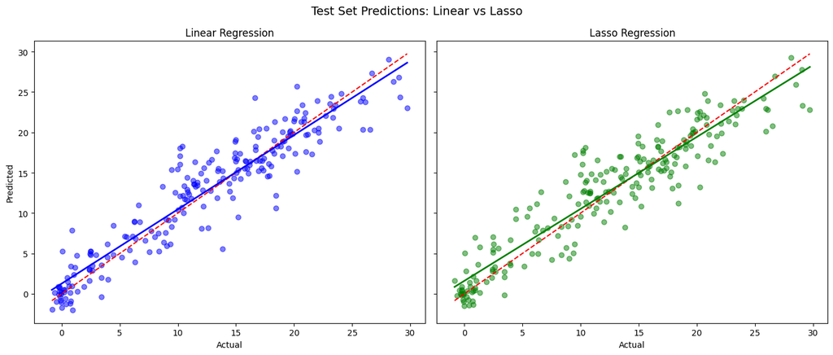

```python
x_vals = np.linspace(y_test.min(), y_test.max(), 200)
linear_fit = np.poly1d(np.polyfit(y_test, y_test_pred, 1))
lasso_fit  = np.poly1d(np.polyfit(y_test, y_test_pred_lasso, 1))

fig, axes = plt.subplots(1, 2, figsize=(14, 6), sharex=True, sharey=True)

# Linear
axes[0].scatter(y_test, y_test_pred, alpha=0.5, color='blue')
axes[0].plot(x_vals, x_vals, 'r--', linewidth=1.5)
axes[0].plot(x_vals, linear_fit(x_vals), color='blue', linewidth=2)
axes[0].set_title("Linear Regression")
axes[0].set_xlabel("Actual")
axes[0].set_ylabel("Predicted")

# Lasso
axes[1].scatter(y_test, y_test_pred_lasso, alpha=0.5, color='green')
axes[1].plot(x_vals, x_vals, 'r--', linewidth=1.5)
axes[1].plot(x_vals, lasso_fit(x_vals), color='green', linewidth=2)
axes[1].set_title("Lasso Regression")
axes[1].set_xlabel("Actual")

plt.suptitle("Test Set Predictions: Linear vs Lasso", fontsize=14)
plt.tight_layout()
plt.show()
```

## Conclusion and Key Insights

### Visualization: Explaining the Primary Analysis

To clearly show how well our models work, we used two main types of plots. First, we generated Actual vs. Predicted Fantasy Points scatter plots for both the Linear and the Lasso Regression models. In these plots, the goal is to see how close the model's predictions are to the real-world results. The horizontal line on the graph represents the actual fantasy points a quarterback earned in a given season, while the vertical axis shows the predicted score from our model. We also include a red dashed line, which represents what a perfect prediction would look like a 45-degree line where the actual score exactly equals the predicted score. Looking at the plots, the blue dots representing Linear Regression and the green dots representing Lasso Regression are both tightly packed and follow this red dashed line very closely. This tight grouping is visual proof that both models are highly accurate at predicting quarterback fantasy performance. Numerically, this accuracy is confirmed by the high R² scores we achieved on our test data: approximately 0.88 for Linear Regression and 0.87 for Lasso Regression. An R² value this close to 1.0 means the model is explaining almost 88% of the variability in quarterback fantasy scores.